# __notebook__

## KEYWORDS:

### * Ordinary Least Squares (OLS) Regression: Simple Linear Regression, Polynomial Regression, and Multiple Linear Regression

### * Exploring and Preparing the Data, Model Building, Variable Importance, Regression Assumptions, Improving model performance

### * Log Transformation, Outliers Remove Function, Multicollinearity Check, Statistical Interpretation

```r
library(psych)
library(relaimpo)
library(rcompanion)
library(MASS)
library(car)
library(leaps)
```

```r
insurance <- read.csv("../input/insurance/insurance.csv")
str(insurance)
```

```
'data.frame':	1338 obs. of  7 variables:
 $ age     : int  19 18 28 33 32 31 46 37 37 60 ...
 $ sex     : Factor w/ 2 levels "female","male": 1 2 2 2 2 1 1 1 2 1 ...
 $ bmi     : num  27.9 33.8 33 22.7 28.9 ...
 $ children: int  0 1 3 0 0 0 1 3 2 0 ...
 $ smoker  : Factor w/ 2 levels "no","yes": 2 1 1 1 1 1 1 1 1 1 ...
 $ region  : Factor w/ 4 levels "northeast","northwest",..: 4 3 3 2 2 3 3 2 1 2 ...
 $ charges : num  16885 1726 4449 21984 3867 ...
```

# Exploring and preparing the data

### We begin by looking at response (dependent) variable , "charges".

```r
summary(insurance$charges)
```

```
   Min. 1st Qu.  Median    Mean 3rd Qu.    Max.
   1122    4740    9382   13270   16640   63770
```

### Because the mean value is greater than the median, this implies that the distribution of insurance expenses is right-skewed. We can confirm this visually using a histogram or density plot:

```r
par(mfrow = c(1,2)) # combine the two plots
hist(insurance$charges, main = "Histogram of charges", col = "lightblue")
plot(density(insurance$charges), main = "Density plot of charges")
polygon(density(insurance$charges), col = "orange")
```

[figure not shown]

### In regression situations, highly skewed data can result in a pooly fitting model. When all of the values are *positive*, the log (natural logarithm) transformation that can often be used to normalize highly skewed data.

```r
insurance$charges <- log(insurance$charges)
summary(insurance$charges)
par(mfrow = c(1,2))
hist(insurance$charges, main = "Histogram of charges", col = "lightblue")
plot(density(insurance$charges), main = "Density plot of charges")
polygon(density(insurance$charges), col = "orange")
```

```
   Min. 1st Qu.  Median    Mean 3rd Qu.    Max.
  7.023   8.464   9.147   9.099   9.720  11.063
```

[figure not shown]

### We can see this log transformation gives us a much less skewed and more symmetric distrubution.

## We now examine the other variable.

- 3 factor: sex, smoker, region
- 3 numerical: age, bmi, children

```r
par(mfrow = c(1,3))
barplot(table(insurance$sex), main = "sex")
barplot(table(insurance$smoker), main = "smoker")
barplot(table(insurance$region), main = "region")
```

[figure not shown]

```r
par(mfrow = c(1,3))
hist(insurance$age, main = "Histogram of age", col = "lightblue")
hist(insurance$bmi, main = "Histogram of bmi", col = "lightblue")
hist(insurance$children, main = "Histogram of children", col = "lightblue")
```

[figure not shown]

### * Check the outliers using the boxplot.

```r
par(mfrow = c(1,3))
boxplot(insurance$age, main = "Histogram of age")
boxplot(insurance$bmi, main = "Histogram of bmi")
boxplot(insurance$children, main = "Histogram of children")
```

[figure not shown]

We can see the 'bmi' has outliters. Remove the outliers from the data set.

```r
outliers_remover <- function(a){
  df <- a
  aa <- c()
  count <- 1
  for(i in 1:ncol(df)){
    if(is.numeric(df[,i])){
      Q3 <- quantile(df[,i], 0.75, na.rm = TRUE)
      Q1 <- quantile(df[,i], 0.25, na.rm = TRUE)
      IQR <- Q3 - Q1  #IQR(df[,i])
      upper <- Q3 + 1.5 * IQR
      lower <- Q1 - 1.5 * IQR
      for(j in 1:nrow(df)){
        if(is.na(df[j,i]) == TRUE){
            next
        }

        else if(df[j,i] > upper | df[j,i] < lower){
          aa[count] <- j
          count <- count+1
        }
      }
    }
  }

  df <- df[-aa,]
}

insurance_new <- outliers_remover(insurance)
str(insurance_new)
```

```
'data.frame':	1329 obs. of  7 variables:
 $ age     : int  19 18 28 33 32 31 46 37 37 60 ...
 $ sex     : Factor w/ 2 levels "female","male": 1 2 2 2 2 1 1 1 2 1 ...
 $ bmi     : num  27.9 33.8 33 22.7 28.9 ...
 $ children: int  0 1 3 0 0 0 1 3 2 0 ...
 $ smoker  : Factor w/ 2 levels "no","yes": 2 1 1 1 1 1 1 1 1 1 ...
 $ region  : Factor w/ 4 levels "northeast","northwest",..: 4 3 3 2 2 3 3 2 1 2 ...
 $ charges : num  9.73 7.45 8.4 10 8.26 ...
```

Compare original data, we can see the observations reduced from 1338 to 1329.

## Check the Correlation Coefficient between dependentvariables.

Correlation coefficient is between -1 and 1.

### * Correlation matrix ( **'x' must be numeric**)

```r
cor(insurance_new[c("age", "bmi", "children")])
```

A matrix: 3 Ã 3 of type dbl

|  | age | bmi | children |
| --- | --- | --- | --- |
| age | 1.00000000 | 0.1146860 | 0.04304057 |
| bmi | 0.11468605 | 1.0000000 | 0.01735450 |
| children | 0.04304057 | 0.0173545 | 1.00000000 |

### We also can creat a scatterplot matrix using pairs.panels() function.

```r
#library(psych)
pairs.panels(insurance_new[c("age", "sex", "bmi", "children", "smoker", "region")], digits = 2, cor = TRUE, main = "Insurance Scatterplot Matrix")
```

[figure not shown]

#### Depend on the scatterplot matrix above, there are not multicollinearity. None of the pairwise correlations among age, sex, bmi, children, smoker, and region are particularly strong (r < 0.2 in each case).

### **[> 0.7 is multicollinearity]**

### In the scatterplot matrix:

- red dot shows mean
- red line is Loess curve
- the circle, more round most no correlation, more oval more correlation

# Model Building

## * Simple linear regression

```r
sl_model <- lm(charges ~ age, data = insurance_new)
summary(sl_model)
```

```
Call:
lm(formula = charges ~ age, data = insurance_new)

Residuals:
    Min      1Q  Median      3Q     Max
-1.3421 -0.4150 -0.3075  0.5001  2.2012

Coefficients:
            Estimate Std. Error t value Pr(>|t|)
(Intercept) 7.743223   0.063274  122.38   <2e-16 ***
age         0.034533   0.001519   22.73   <2e-16 ***
---
Signif. codes:  0 â***â 0.001 â**â 0.01 â*â 0.05 â.â 0.1 â â 1

Residual standard error: 0.7778 on 1327 degrees of freedom
Multiple R-squared:  0.2802,	Adjusted R-squared:  0.2796
F-statistic: 516.5 on 1 and 1327 DF,  p-value: < 2.2e-16
```

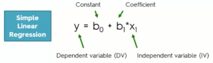

### From the output, we can see the prediction equation is

#### charges = 7.74 + 0.03 * age （numbers from Estimate column)

#### From the Pr(>|t|) column, we see that the regression coefficient(0.03) is significantly different from zero(p<0.001) and indicates that there's an expected increase of 0.03 of charges for every 1 year increase in age.

#### The multiple R-squared(0.2802) indicates that the model accounts for 28.02% of the variance in charges. The multiple R-squared is also the squared correlation between the actual and predicted value.

#### The residual standard error(0.7778) can be thought of as the average error in predicting charges from age using this model.

#### The F-statistic tests whether the predictor variables, taken together, predict the response variable above chance levels.

## * Multiple linear regression

```r
mul_model <- lm(charges ~ age + sex + bmi + children + smoker + region, data = insurance_new)
# mul_model_ <- lm(charges ~ ., data = insurance_new)
summary(mul_model)
```

```
Call:
lm(formula = charges ~ age + sex + bmi + children + smoker +
    region, data = insurance_new)

Residuals:
     Min       1Q   Median       3Q      Max
-0.96230 -0.20335 -0.05116  0.06689  2.15774

Coefficients:
                  Estimate Std. Error t value Pr(>|t|)
(Intercept)      7.0189810  0.0736299  95.328  < 2e-16 ***
age              0.0345063  0.0008747  39.451  < 2e-16 ***
sexmale         -0.0733876  0.0244581  -3.001 0.002746 **
bmi              0.0139382  0.0021569   6.462 1.45e-10 ***
children         0.1013442  0.0101028  10.031  < 2e-16 ***
smokeryes        1.5476697  0.0304112  50.891  < 2e-16 ***
regionnorthwest -0.0649379  0.0348976  -1.861 0.062993 .
regionsoutheast -0.1568938  0.0351508  -4.463 8.75e-06 ***
regionsouthwest -0.1313801  0.0350540  -3.748 0.000186 ***
---
Signif. codes:  0 â***â 0.001 â**â 0.01 â*â 0.05 â.â 0.1 â â 1

Residual standard error: 0.4438 on 1320 degrees of freedom
Multiple R-squared:  0.7669,	Adjusted R-squared:  0.7655
F-statistic: 542.9 on 8 and 1320 DF,  p-value: < 2.2e-16
```

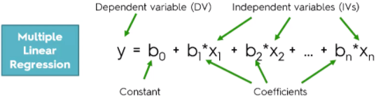

#### charges = 7.02 + 0.03 *age + (-0.07)* sexmale + 0.01 *bmi + 0.10* children + ....

#### When there's more than one independent variable, the regression coefficients indicate the increase in the dependent variable for a unit change in a predictor varable, holding all other independent variables constant. For example, the regression cofficient for bmi is 0.01, suggesting that an increase of 1 in bmi is associated with a 0.01 increase in the charges, controlling for age, sex, children......

# Choose the Important Variables

### 1. Relative importance of Variables

```r
#library(relaimpo)
relative_importance <- calc.relimp(mul_model, type = "lmg", rela = TRUE)
sort(relative_importance$lmg, decreasing = TRUE)
```

**smoker**

0.585482362636733

**age**

0.362994642745954

**children**

0.0286046054400546

**bmi**

0.0164892654585452

**region**

0.00520408808542937

**sex**

0.00122503563328379

### 2. Stepwise Regression

Stepwise regression provides a number of stopping rules for selecting the best subset of variables for our model.  
In stepwise selection, variables are added to or deleted from a model one at a time, until some stopping criterion is reached.

#### Forward stepwise/ backward stepwise

#### Overview the principle

```r
#backward stepwise
mul_model1 <- lm(charges ~ age + sex + bmi + children + smoker + region, data = insurance_new)
mul_model2 <- lm(charges ~ age + sex + bmi + children + smoker,          data = insurance_new)
mul_model3 <- lm(charges ~ age + sex + bmi + children,                   data = insurance_new)
#.........
#library(rcompanion)
com_mod <- compareLM(mul_model1, mul_model2, mul_model3)
com_mod
```

**$Models**

A matrix: 3 Ã 1 of type chr

|  | Formula |
| --- | --- |
| 1 | charges ~ age + sex + bmi + children + smoker + region |
| 2 | charges ~ age + sex + bmi + children + smoker |
| 3 | charges ~ age + sex + bmi + children |

**$Fit.criteria**

A data.frame: 3 Ã 10

| Rank <dbl> | Df.res <dbl> | AIC <dbl> | AICc <dbl> | BIC <dbl> | R.squared <dbl> | Adj.R.sq <dbl> | p.value <dbl> | Shapiro.W <dbl> | Shapiro.p <dbl> |
| --- | --- | --- | --- | --- | --- | --- | --- | --- | --- |
| 9 | 1320 | 1623 | 1623 | 1675 | 0.7669 | 0.7655 | 0.000e+00 | 0.8368 | 7.723e-35 |
| 6 | 1323 | 1641 | 1641 | 1677 | 0.7627 | 0.7618 | 0.000e+00 | 0.8405 | 1.569e-34 |
| 5 | 1324 | 3067 | 3067 | 3098 | 0.3049 | 0.3028 | 5.474e-103 | 0.8369 | 7.969e-35 |

We usually compare the BIC or AIC or AICc.

- **BIC**(Bayesian Information Criterion)-- smallest BIC is better.
- **AIC**(Akaikeâs Information Criterion)-- smallest AIC is better.
- **AICc**(Akaikeâs Information Criterion, with a correction for small sample sizes) -- smallest AICc is better.

These rules (Minimum BIC/AIC/AICc) attempt to explain the relationship between predictors and a response without building models that are overly complex in terms of the number of predictors. Since different criteria are used to determine when to stop adding terms to the model, these stopping rules may lead to different âbestâ models (see Burnham, 2002).

```r
#Check the AIC.
#Sort the result or Create a line chart for AIC values with model numbers on the x axis, and AIC values on the y axis.
com_model <- com_mod$Fit.criteria
com_model[order(com_model$AIC),]
plot(com_model$AIC, type = "b", xlab = "model number", ylab = "AICc value")
```

A data.frame: 3 Ã 10

|  | Rank <dbl> | Df.res <dbl> | AIC <dbl> | AICc <dbl> | BIC <dbl> | R.squared <dbl> | Adj.R.sq <dbl> | p.value <dbl> | Shapiro.W <dbl> | Shapiro.p <dbl> |
| --- | --- | --- | --- | --- | --- | --- | --- | --- | --- | --- |
| 1 | 9 | 1320 | 1623 | 1623 | 1675 | 0.7669 | 0.7655 | 0.000e+00 | 0.8368 | 7.723e-35 |
| 2 | 6 | 1323 | 1641 | 1641 | 1677 | 0.7627 | 0.7618 | 0.000e+00 | 0.8405 | 1.569e-34 |
| 3 | 5 | 1324 | 3067 | 3067 | 3098 | 0.3049 | 0.3028 | 5.474e-103 | 0.8369 | 7.969e-35 |

[figure not shown]

mul_model1 is the best

#### 2.1 Using step(object, scope, scale = 0, direction = c("both", "backward", "forward"), trace = 1, keep = NULL, steps = 1000， k = 2, ...)

```r
base_mod <- lm(charges ~ 1 , data= insurance_new)  # base intercept only model

all_mod <- lm(charges ~ . , data= insurance_new) # full model with all predictors

stepMod <- step(base_mod, scope = list(lower = base_mod, upper = all_mod), direction = "both", trace = 0, steps = 1000)  # perform step-wise algorithm

stepMod
```

```
Call:
lm(formula = charges ~ smoker + age + children + bmi + region +
    sex, data = insurance_new)

Coefficients:
    (Intercept)        smokeryes              age         children
        7.01898          1.54767          0.03451          0.10134
            bmi  regionnorthwest  regionsoutheast  regionsouthwest
        0.01394         -0.06494         -0.15689         -0.13138
        sexmale
       -0.07339
```

#### 2.2 Use stepAIC() function in the MASS package

```r
#library(MASS)
mul_model <- lm(charges ~ age + sex + bmi + children + smoker + region, data = insurance_new)
stepAIC(mul_model, direction = "backward")
```

```
Start:  AIC=-2150.26
charges ~ age + sex + bmi + children + smoker + region

           Df Sum of Sq    RSS      AIC
<none>                  260.00 -2150.26
- sex       1      1.77 261.77 -2143.23
- region    3      4.70 264.70 -2132.47
- bmi       1      8.23 268.23 -2110.87
- children  1     19.82 279.82 -2054.62
- age       1    306.56 566.56 -1117.11
- smoker    1    510.14 770.14  -709.11
```

```
Call:
lm(formula = charges ~ age + sex + bmi + children + smoker +
    region, data = insurance_new)

Coefficients:
    (Intercept)              age          sexmale              bmi
        7.01898          0.03451         -0.07339          0.01394
       children        smokeryes  regionnorthwest  regionsoutheast
        0.10134          1.54767         -0.06494         -0.15689
regionsouthwest
       -0.13138
```

So the model including all 6 dependent variables is the best one.

### 3. Multicollinearity, Variation Inflation Factor (VIF)

Multicollinearity(or substantial correlation) generally occurs when there are high correlations between two or more predictor variables. In other words, one predictor variable can be used to predict the other. For example: a person's hight and weight  
Not as before methods, the VIF checks the model.

#### As a general rule of thumb, a VIF for a predictor greater than 5 or 10 indicates that multicollinearity. or square-root(VIF) > 2 indicates multicollinearity problem.

```r
#library(car)
vif(mul_model)
sqrt(vif(mul_model)) > 2
```

A matrix: 6 Ã 3 of type dbl

|  | GVIF | Df | GVIF^(1/(2*Df)) |
| --- | --- | --- | --- |
| age | 1.017899 | 1 | 1.008910 |
| sex | 1.008977 | 1 | 1.004478 |
| bmi | 1.099198 | 1 | 1.048427 |
| children | 1.004071 | 1 | 1.002034 |
| smoker | 1.012968 | 1 | 1.006463 |
| region | 1.090560 | 3 | 1.014553 |

A matrix: 6 Ã 3 of type lgl

|  | GVIF | Df | GVIF^(1/(2*Df)) |
| --- | --- | --- | --- |
| age | FALSE | FALSE | FALSE |
| sex | FALSE | FALSE | FALSE |
| bmi | FALSE | FALSE | FALSE |
| children | FALSE | FALSE | FALSE |
| smoker | FALSE | FALSE | FALSE |
| region | FALSE | FALSE | FALSE |

### 4. Best Subsets

Best subsets is a technique that relies on stepwise regression to search, find and visualize regression models. Unlike stepwise regression, we have more options to see what variables were included in various shortlisted models we can visually inspect the modelâs performance w.r.t Adj R-sq.

```r
#library(leaps)
subsets <- regsubsets(charges ~., data = insurance_new, nbest = 2)
subsets
```

```
Subset selection object
Call: regsubsets.formula(charges ~ ., data = insurance_new, nbest = 2)
8 Variables  (and intercept)
                Forced in Forced out
age                 FALSE      FALSE
sexmale             FALSE      FALSE
bmi                 FALSE      FALSE
children            FALSE      FALSE
smokeryes           FALSE      FALSE
regionnorthwest     FALSE      FALSE
regionsoutheast     FALSE      FALSE
regionsouthwest     FALSE      FALSE
2 subsets of each size up to 8
Selection Algorithm: exhaustive
```

```r
plot(subsets, scale = "r2") # regsubsets plot based on R-sq
abline(h=4, v=0, col="red")
abline(h=10, v=0, col="green")
```

[figure not shown]

### * In most instances, all subsets regression is preferable to stepwise regression,

# Check model assumptions

### 1. Check normality of errors:

we can create a histogram of residuals from a linear model. The distribution of these residuals should be approximately normal. We can find the residuals of a model by using residuals() function.

```r
mod_re <- residuals(mul_model)
hist(mod_re)
```

[figure not shown]

We can see the distribution of these residuals is not approximately normal.

### 2. Check the linearity between residuals and predicted values. The residuals should be unbiased and homoscedastic

### 3. Type plot(mul_model) to see the independence of errors.

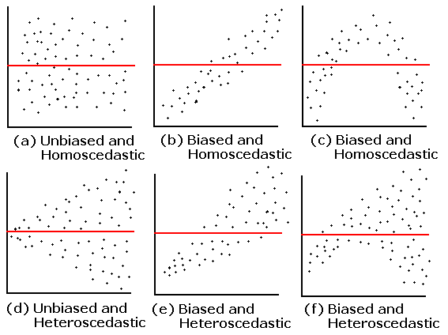

```r
par(mfrow=c(2,2))
plot(mul_model)
```

[figure not shown]

*top-left* and *bottom-left* plots show how the residuals vary as the fitted values increase. The dots should be randomly placed around the horizontal zero line.

The distribution of residuals with normal quantile plot (*top-right*) is a probability plot of the standardized residuals against the values that would be expected under normality. If we've met the normality assumption, the points on the graph should fall on the straight 45-degree line.

*bottom-right* is the plot of standardized residuals against the leverage. Leverage is a measure of how much each data point influences the regression. A part the red smoothed line is not stay close to the mid-line and some point have a large Cook's distance(Cook's D), which reflects how much the fitted values would change if a point was deleted.

Cook's D is one of two methods for identifying influential observations. Cook's D values greater than 4/(n-k-1), where n is the sample size and k is the number of predictor variables, indicate influential observations.

# Improving model performance

### 1. Adding nonlinear relations(Polynomial regression)

To account for a non-linear relationship, we can add a higher order term to the regression model, treating the model as a polynomial. In effect, we will be modeling a relationship like this:

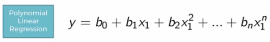

```r
insurance_new$age2 <- insurance_new$age^2
```

### 2. Transformation -- converting a numeric variable to a binary indicator

```r
insurance_new$bmi30 <- ifelse(insurance_new$bmi >= 30, 1, 0)
```

### 3. Model specification -- adding interaction effects

To have the obesity indicator(bmi30) and the smoking indicator(smoker) interact

charges ~ bmi30 * smoker

### To summarize the improvements:

- Added a non-linear term for age
- Created an indicator for obesity
- Specified an interaction between obesity and smoking

```r
im_model <- lm(charges ~ age + age2 + children +bmi + sex + bmi30*smoker + region, data = insurance_new)
summary(im_model)
```

```
Call:
lm(formula = charges ~ age + age2 + children + bmi + sex + bmi30 *
    smoker + region, data = insurance_new)

Residuals:
     Min       1Q   Median       3Q      Max
-0.80328 -0.18884 -0.06975  0.05380  2.25498

Coefficients:
                  Estimate Std. Error t value Pr(>|t|)
(Intercept)      6.922e+00  1.322e-01  52.352  < 2e-16 ***
age              5.329e-02  5.709e-03   9.335  < 2e-16 ***
age2            -2.341e-04  7.118e-05  -3.289 0.001031 **
children         9.301e-02  1.009e-02   9.221  < 2e-16 ***
bmi              7.401e-03  3.432e-03   2.156 0.031243 *
sexmale         -8.596e-02  2.334e-02  -3.682 0.000241 ***
bmi30           -3.613e-02  4.119e-02  -0.877 0.380505
smokeryes        1.215e+00  4.188e-02  29.003  < 2e-16 ***
regionnorthwest -6.083e-02  3.327e-02  -1.828 0.067729 .
regionsoutheast -1.513e-01  3.357e-02  -4.508 7.14e-06 ***
regionsouthwest -1.389e-01  3.342e-02  -4.155 3.47e-05 ***
bmi30:smokeryes  6.357e-01  5.780e-02  10.997  < 2e-16 ***
---
Signif. codes:  0 â***â 0.001 â**â 0.01 â*â 0.05 â.â 0.1 â â 1

Residual standard error: 0.4231 on 1317 degrees of freedom
Multiple R-squared:  0.7887,	Adjusted R-squared:  0.7869
F-statistic: 446.9 on 11 and 1317 DF,  p-value: < 2.2e-16
```

```r
par(mfrow=c(2,2))
plot(im_model)
```

[figure not shown]

```r
insurance <- read.csv("../input/insurance/insurance.csv")
insurance$charges <- log(insurance$charges)
insurance_new <- outliers_remover(insurance)

# Create Training and Test data -- model1 (before the improvments)
trainingRowIndex <- sample(1:nrow(insurance_new), 0.7 * nrow(insurance_new)) #row indices for training data
trainingData <- insurance_new[trainingRowIndex,] #training data
testData <- insurance_new[-trainingRowIndex,] #test data
# Build the model on training data
model1 <- lm(charges ~ age + sex + bmi + children + smoker + region, data = trainingData)
# predict
pred1 <- predict(model1, testData)
actuals_preds1 <- data.frame(cbind(actuals = testData$charges, predicted = pred1))
cor(actuals_preds1)
```

A matrix: 2 Ã 2 of type dbl

|  | actuals | predicted |
| --- | --- | --- |
| actuals | 1.0000000 | 0.8644936 |
| predicted | 0.8644936 | 1.0000000 |

```r
insurance <- read.csv("../input/insurance/insurance.csv")
insurance$charges <- log(insurance$charges)
insurance_new <- outliers_remover(insurance)
insurance_new$age2 <- insurance_new$age^2
insurance_new$bmi30 <- ifelse(insurance_new$bmi >= 30, 1, 0)

# Create Training and Test data -- model2 (after the improvments)
trainingRowIndex <- sample(1:nrow(insurance_new), 0.7 * nrow(insurance_new)) #row indices for training data
trainingData <- insurance_new[trainingRowIndex,] #training data
testData <- insurance_new[-trainingRowIndex,] #test data
# Build the model on training data
model2 <- lm(charges ~ age + sex + bmi + children + smoker + region, data = trainingData)
# predict
pred2 <- predict(model2, testData)
actuals_preds2 <- data.frame(cbind(actuals = testData$charges, predicted = pred2))
cor(actuals_preds2)
```

A matrix: 2 Ã 2 of type dbl

|  | actuals | predicted |
| --- | --- | --- |
| actuals | 1.0000000 | 0.8953757 |
| predicted | 0.8953757 | 1.0000000 |